# PQHS471_ Midterm

Andrew Shan

3/8/2018

```r
library(knitr)
library(rmdformats)
library(arm)
library(leaps)
library(tableone)
library(pander)
library(MASS)
library(ROCR)
library(skimr)
library(rms)
library(broom)
library(dplyr)
library(tidyverse)
```

# Load and Tidy the Data

```r
test <- read.csv("census_test.csv")
train <- read.csv("census_train.csv")
```

```r
skim(train)
```

```
Skim summary statistics
 n obs: 25000
 n variables: 15

Variable type: factor
       variable missing complete     n n_unique
      education       0    25000 25000       16
         income       0    25000 25000        2
 marital.status       0    25000 25000        7
 native.country       0    25000 25000       42
     occupation       0    25000 25000       15
           race       0    25000 25000        5
   relationship       0    25000 25000        6
            sex       0    25000 25000        2
      workclass       0    25000 25000        9
                                  top_counts ordered
   HS: 8064,  So: 5585,  Ba: 4105,  Ma: 1304   FALSE
                 <=: 19002,  >5: 5998, NA: 0   FALSE
   Ma: 11493,  Ne: 8196,  Di: 3425,  Se: 790   FALSE
      Un: 22394,  Me: 501,  ?: 437,  Ph: 154   FALSE
   Pr: 3186,  Cr: 3160,  Ex: 3146,  Ad: 2885   FALSE
    Wh: 21370,  Bl: 2369,  As: 806,  Am: 239   FALSE
  Hu: 10117,  No: 6370,  Ow: 3887,  Un: 2626   FALSE
                 Ma: 16787,  Fe: 8213, NA: 0   FALSE
   Pr: 17447,  Se: 1943,  Lo: 1606,  ?: 1404   FALSE

Variable type: integer
       variable missing complete     n      mean        sd    p0    p25
            age       0    25000 25000     38.6      13.64    17     28
   capital.gain       0    25000 25000   1074.33   7358.75     0      0
   capital.loss       0    25000 25000     88.31    404.42     0      0
  education.num       0    25000 25000     10.07      2.57     1      9
         fnlwgt       0    25000 25000 189625.48 105413.94 12285 117833
 hours.per.week       0    25000 25000     40.41     12.38     1     40
 median       p75    p100     hist
     37     48         90 ▇▇▇▆▃▁▁▁
      0      0      99999 ▇▁▁▁▁▁▁▁
      0      0       4356 ▇▁▁▁▁▁▁▁
     10     12         16 ▁▁▁▁▇▁▃▁
 178302 236986.25 1484705 ▇▅▁▁▁▁▁▁
     40     45         99 ▁▁▁▇▁▁▁▁
```

```r
skim(test)
```

```
Skim summary statistics
 n obs: 7561
 n variables: 15

Variable type: factor
       variable missing complete    n n_unique
      education       0     7561 7561       16
         income       0     7561 7561        2
 marital.status       0     7561 7561        7
 native.country       0     7561 7561       41
     occupation       0     7561 7561       15
           race       0     7561 7561        5
   relationship       0     7561 7561        6
            sex       0     7561 7561        2
      workclass       0     7561 7561        8
                                top_counts ordered
  HS: 2437,  So: 1706,  Ba: 1250,  Ma: 419   FALSE
                <=: 5718,  >5: 1843, NA: 0   FALSE
  Ma: 3483,  Ne: 2487,  Di: 1018,  Wi: 242   FALSE
      Un: 6776,  ?: 146,  Me: 142,  Ph: 44   FALSE
     Pr: 954,  Cr: 939,  Ex: 920,  Ad: 885   FALSE
     Wh: 6446,  Bl: 755,  As: 233,  Am: 72   FALSE
  Hu: 3076,  No: 1935,  Ow: 1181,  Un: 820   FALSE
                Ma: 5003,  Fe: 2558, NA: 0   FALSE
     Pr: 5249,  Se: 598,  Lo: 487,  ?: 432   FALSE

Variable type: integer
       variable missing complete    n      mean        sd    p0    p25
            age       0     7561 7561     38.53     13.63    17     28
   capital.gain       0     7561 7561   1088.62   7472.86     0      0
   capital.loss       0     7561 7561     83.97    398.11     0      0
  education.num       0     7561 7561     10.1       2.58     1      9
         fnlwgt       0     7561 7561 190283.87 106003.94 19395 117789
 hours.per.week       0     7561 7561     40.53     12.26     1     40
 median    p75    p100     hist
     37     47      90 ▇▇▇▆▃▂▁▁
      0      0   99999 ▇▁▁▁▁▁▁▁
      0      0    4356 ▇▁▁▁▁▁▁▁
     10     13      16 ▁▁▁▁▇▁▃▁
 178644 237498 1455435 ▇▅▁▁▁▁▁▁
     40     45      99 ▁▁▁▇▁▁▁▁
```

```r
names(train)
```

```
 [1] "age"            "workclass"      "fnlwgt"         "education"
 [5] "education.num"  "marital.status" "occupation"     "relationship"
 [9] "race"           "sex"            "capital.gain"   "capital.loss"
[13] "hours.per.week" "native.country" "income"
```

```r
dim(train)
```

```
[1] 25000    15
```

# Check categorical variables

```r
levels(train$native.country)
```

```
 [1] " ?"                          " Cambodia"
 [3] " Canada"                     " China"
 [5] " Columbia"                   " Cuba"
 [7] " Dominican-Republic"         " Ecuador"
 [9] " El-Salvador"                " England"
[11] " France"                     " Germany"
[13] " Greece"                     " Guatemala"
[15] " Haiti"                      " Holand-Netherlands"
[17] " Honduras"                   " Hong"
[19] " Hungary"                    " India"
[21] " Iran"                       " Ireland"
[23] " Italy"                      " Jamaica"
[25] " Japan"                      " Laos"
[27] " Mexico"                     " Nicaragua"
[29] " Outlying-US(Guam-USVI-etc)" " Peru"
[31] " Philippines"                " Poland"
[33] " Portugal"                   " Puerto-Rico"
[35] " Scotland"                   " South"
[37] " Taiwan"                     " Thailand"
[39] " Trinadad&Tobago"            " United-States"
[41] " Vietnam"                    " Yugoslavia"
```

```r
library(rockchalk)
train$native.country <- combineLevels(train$native.country,levs = c(" ?"," Cambodia"," Canada"," China"," Columbia"," Cuba",                       " Dominican-Republic"," Ecuador"," El-Salvador"," England"," France"," Germany" ," Greece"," Guatemala" , " Haiti",                      " Holand-Netherlands" ," Honduras"," Hong"," Hungary"," India"," Iran"," Ireland"," Italy" , " Jamaica" ," Japan",                      " Laos"," Mexico"," Nicaragua"," Outlying-US(Guam-USVI-etc)"," Peru"," Philippines"," Poland" ," Portugal" ,
                                                                    " Puerto-Rico"," Scotland"," South"," Taiwan" , " Thailand",
                                                                    " Trinadad&Tobago"," Vietnam", " Yugoslavia"),
                                      newLabel = c("Non-US") )
```

```
The original levels  ?  Cambodia  Canada  China  Columbia  Cuba  Dominican-Republic  Ecuador  El-Salvador  England  France  Germany  Greece  Guatemala  Haiti  Holand-Netherlands  Honduras  Hong  Hungary  India  Iran  Ireland  Italy  Jamaica  Japan  Laos  Mexico  Nicaragua  Outlying-US(Guam-USVI-etc)…
have been replaced by  United-States Non-US
```

```r
levels(train$education)
```

```
 [1] " 10th"         " 11th"         " 12th"         " 1st-4th"
 [5] " 5th-6th"      " 7th-8th"      " 9th"          " Assoc-acdm"
 [9] " Assoc-voc"    " Bachelors"    " Doctorate"    " HS-grad"
[13] " Masters"      " Preschool"    " Prof-school"  " Some-college"
```

```r
train$education <- combineLevels(train$education,levs = c(" 10th"," 11th"," 12th"," 1st-4th"," 5th-6th"," 7th-8th"," 9th"," Preschool",
                                                          " HS-grad"),newLabel = c("High School and below") )
```

```
The original levels  10th  11th  12th  1st-4th  5th-6th  7th-8th  9th  Assoc-acdm  Assoc-voc  Bachelors  Doctorate  HS-grad  Masters  Preschool  Prof-school  Some-college
have been replaced by  Assoc-acdm  Assoc-voc  Bachelors  Doctorate  Masters  Prof-school  Some-college High School and below
```

```r
train$education <- combineLevels(train$education,levs = c(" Assoc-acdm"," Assoc-voc"," Some-college" ),newLabel = c("some college") )
```

```
The original levels  Assoc-acdm  Assoc-voc  Bachelors  Doctorate  Masters  Prof-school  Some-college High School and below
have been replaced by  Bachelors  Doctorate  Masters  Prof-school High School and below some college
```

```r
train$education <- combineLevels(train$education,levs = c(" Bachelors"," Doctorate"," Masters"," Prof-school"),newLabel = c("Bachelors and above") )
```

```
The original levels  Bachelors  Doctorate  Masters  Prof-school High School and below some college
have been replaced by High School and below some college Bachelors and above
```

```r
train$income <- combineLevels(train$income,levs = c(" <=50K"),newLabel = c("0") )
```

```
The original levels  <=50K  >50K
have been replaced by  >50K 0
```

```r
train$income <- combineLevels(train$income,levs = c(" >50K"),newLabel = c("1") )
```

```
The original levels  >50K 0
have been replaced by 0 1
```

First, we want to check if it is necessary for some of the categorical variables to combine some levels together. We combine the variable `native.country` to two category `United States` and `Non-US`. Also, we combine 16 levels in the variable `education` into 3 categories `High School and below`, `some college`, and `Bachelors and above`. In order to build our logistic model, we re code levels of `income` into **0** and **1** where **0** stands for income less than or equal to 50K and **1** stands for income more than 50K.

# Quantative variables

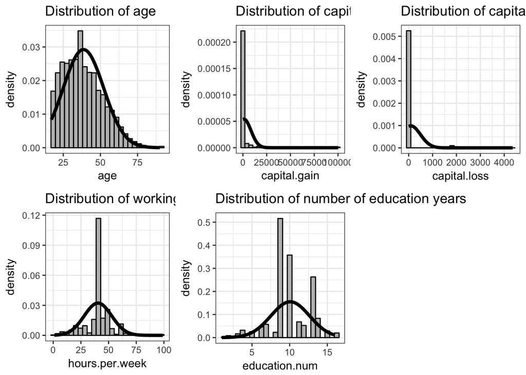

```r
p1<- ggplot(train, aes(x = age)) + geom_histogram(aes(y = ..density..),bins=25, color = "black", fill = "grey") +
  stat_function(fun = dnorm,args = list(mean = mean(train$age), sd = sd(train$age)),
                lwd = 1.5, col = "black") +
  theme_bw()+labs(title = "Distribution of age")

p2<- ggplot(train, aes(x =  capital.gain)) + geom_histogram(aes(y = ..density..),bins=25, color = "black", fill = "grey") +
  stat_function(fun = dnorm,args = list(mean = mean(train$capital.gain), sd = sd(train$ capital.gain)),
                lwd = 1.5, col = "black") +
  theme_bw()+labs(title = "Distribution of capital gain")
p3<- ggplot(train, aes(x =  capital.loss)) + geom_histogram(aes(y = ..density..),bins=25, color = "black", fill = "grey") +
  stat_function(fun = dnorm,args = list(mean = mean(train$capital.loss), sd = sd(train$capital.loss)),
                lwd = 1.5, col = "black") +
  theme_bw()+labs(title = "Distribution of capital loss")
p4<- ggplot(train, aes(x =  hours.per.week)) + geom_histogram(aes(y = ..density..),bins=25, color = "black", fill = "grey") +
  stat_function(fun = dnorm,args = list(mean = mean(train$ hours.per.week), sd = sd(train$ hours.per.week)),
                lwd = 1.5, col = "black") +
  theme_bw()+labs(title = "Distribution of working hours per week ")
p5<- ggplot(train, aes(x = education.num)) + geom_histogram(aes(y = ..density..),bins=25, color = "black", fill = "grey") +
  stat_function(fun = dnorm,args = list(mean = mean(train$education.num), sd = sd(train$education.num)),
                lwd = 1.5, col = "black") +
  theme_bw()+labs(title = "Distribution of number of education years ")

gridExtra::grid.arrange(p1, p2, p3, p4,p5, nrow = 2)
```

# Test dataset

We did the same treatment to test dataset as to train dataset.

```r
test$education <- combineLevels(test$education,levs = c(" 10th"," 11th"," 12th"," 1st-4th"," 5th-6th"," 7th-8th"," 9th"," Preschool",
                                                          " HS-grad"),newLabel = c("High School and below") )
```

```
The original levels  10th  11th  12th  1st-4th  5th-6th  7th-8th  9th  Assoc-acdm  Assoc-voc  Bachelors  Doctorate  HS-grad  Masters  Preschool  Prof-school  Some-college
have been replaced by  Assoc-acdm  Assoc-voc  Bachelors  Doctorate  Masters  Prof-school  Some-college High School and below
```

```r
test$education <- combineLevels(test$education,levs = c(" Assoc-acdm"," Assoc-voc"," Some-college" ),newLabel = c("some college") )
```

```
The original levels  Assoc-acdm  Assoc-voc  Bachelors  Doctorate  Masters  Prof-school  Some-college High School and below
have been replaced by  Bachelors  Doctorate  Masters  Prof-school High School and below some college
```

```r
test$education <- combineLevels(test$education,levs = c(" Bachelors"," Doctorate"," Masters"," Prof-school"),newLabel = c("Bachelors and above") )
```

```
The original levels  Bachelors  Doctorate  Masters  Prof-school High School and below some college
have been replaced by High School and below some college Bachelors and above
```

```r
test$income <- combineLevels(test$income,levs = c(" <=50K"),newLabel = c("0") )
```

```
The original levels  <=50K  >50K
have been replaced by  >50K 0
```

```r
test$income <- combineLevels(test$income,levs = c(" >50K"),newLabel = c("1") )
```

```
The original levels  >50K 0
have been replaced by 0 1
```

```r
test$native.country <- combineLevels(test$native.country,levs = c(" ?"," Cambodia"," Canada"," China"," Columbia",
                                                                    " Cuba"," Dominican-Republic"," Ecuador"," El-Salvador",
                                                                    " England" ," France"," Germany"," Greece", " Guatemala",
                                                                    " Haiti"," Honduras"," Hong"," Hungary"," India",
                                                                    " Iran"," Ireland"," Italy"," Jamaica"," Japan",
                                                                    " Laos" ," Mexico"," Nicaragua", " Outlying-US(Guam-USVI-etc)",
                                                                    " Peru"," Philippines"," Poland"," Portugal",
                                                                    " Puerto-Rico"," Scotland"," South"," Taiwan",
                                                                    " Thailand"," Trinadad&Tobago"," Vietnam",
                                                                    " Yugoslavia"),
                                      newLabel = c("Non-US") )
```

```
The original levels  ?  Cambodia  Canada  China  Columbia  Cuba  Dominican-Republic  Ecuador  El-Salvador  England  France  Germany  Greece  Guatemala  Haiti  Honduras  Hong  Hungary  India  Iran  Ireland  Italy  Jamaica  Japan  Laos  Mexico  Nicaragua  Outlying-US(Guam-USVI-etc)  Peru  Philippines …
have been replaced by  United-States Non-US
```

# Codebook

```r
a <- dput(names(train))
```

```
c("age", "workclass", "fnlwgt", "education", "education.num",
"marital.status", "occupation", "relationship", "race", "sex",
"capital.gain", "capital.loss", "hours.per.week", "native.country",
"income")
```

```r
options(width = 200)
b <- c("age at baseline",
       "Working class",
       "The final sample weight",
       "Education level",
       "Number of years spent on education",
       "Marriage status",
       "Ocupation",
       "Role in family",
       "Race",
       "Sex",
       "Capital gain in a year",
       "Capital loss in a year",
       "hours spent on work per week",
       "Country born in",
       "Total income")
c <- map(train, function(x) class(x))
d <- map(train, function(x) sum(is.na(x)))
e <- map(train, function(x) ifelse(is.factor(x) == T, "--", min(x, na.rm=T)))
f <- map(train, function(x) ifelse(is.factor(x) == T, "--", max(x, na.rm=T)))

train.CB <- data_frame(Variable = a, Description = b, Class = c, Missing = d, Min = e, Max = f)
pander(train.CB)
```

Table continues below

| Variable | Description | Class | Missing | Min |
| --- | --- | --- | --- | --- |
| age | age at baseline | integer | 0 | 17 |
| workclass | Working class | factor | 0 | – |
| fnlwgt | The final sample weight | integer | 0 | 12285 |
| education | Education level | factor | 0 | – |
| education.num | Number of years spent on education | integer | 0 | 1 |
| marital.status | Marriage status | factor | 0 | – |
| occupation | Ocupation | factor | 0 | – |
| relationship | Role in family | factor | 0 | – |
| race | Race | factor | 0 | – |
| sex | Sex | factor | 0 | – |
| capital.gain | Capital gain in a year | integer | 0 | 0 |
| capital.loss | Capital loss in a year | integer | 0 | 0 |
| hours.per.week | hours spent on work per week | integer | 0 | 1 |
| native.country | Country born in | factor | 0 | – |
| income | Total income | factor | 0 | – |

| Max |
| --- |
| 90 |

1484705

–

16

–

–

–

–

–

99999

4356

99

–

```r
rm(a, b, c, d, e)
```

# Losgitc model

```r
names(train)
```

```
 [1] "age"            "workclass"      "fnlwgt"         "education"      "education.num"  "marital.status" "occupation"     "relationship"   "race"           "sex"            "capital.gain"
[12] "capital.loss"   "hours.per.week" "native.country" "income"
```

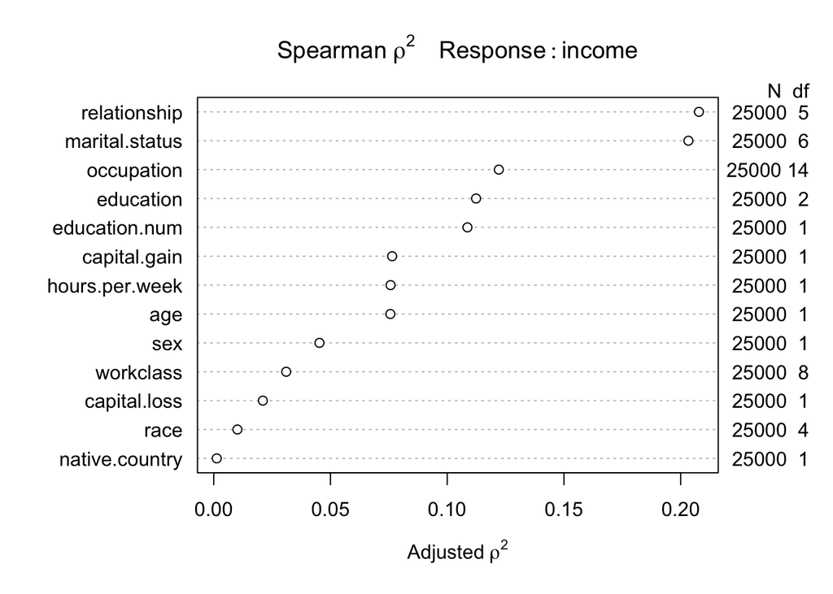

```r
plot(spearman2(income ~ age+workclass+education+education.num+marital.status+occupation+relationship+race+sex
               +capital.gain+capital.loss+hours.per.week+native.country,
               data = train))
```

First, we try to use best subsets to select predcitors.

# Running “Best Subsets” to select predictors

```r
preds <- with(train, cbind(age,workclass,education,education.num,marital.status,occupation,relationship,race,sex,
                            capital.gain,capital.loss,hours.per.week,native.country))
x1 <- regsubsets(preds, train$income, nvmax=13)
rs.sum <- summary(x1)
rs.sum
```

```
Subset selection object
13 Variables  (and intercept)
               Forced in Forced out
age                FALSE      FALSE
workclass          FALSE      FALSE
education          FALSE      FALSE
education.num      FALSE      FALSE
marital.status     FALSE      FALSE
occupation         FALSE      FALSE
relationship       FALSE      FALSE
race               FALSE      FALSE
sex                FALSE      FALSE
capital.gain       FALSE      FALSE
capital.loss       FALSE      FALSE
hours.per.week     FALSE      FALSE
native.country     FALSE      FALSE
1 subsets of each size up to 13
Selection Algorithm: exhaustive
          age workclass education education.num marital.status occupation relationship race sex capital.gain capital.loss hours.per.week native.country
1  ( 1 )  " " " "       " "       "*"           " "            " "        " "          " "  " " " "          " "          " "            " "
2  ( 1 )  "*" " "       " "       "*"           " "            " "        " "          " "  " " " "          " "          " "            " "
3  ( 1 )  "*" " "       " "       "*"           " "            " "        " "          " "  "*" " "          " "          " "            " "
4  ( 1 )  "*" " "       " "       "*"           " "            " "        " "          " "  "*" "*"          " "          " "            " "
5  ( 1 )  "*" " "       " "       "*"           " "            " "        " "          " "  "*" "*"          " "          "*"            " "
6  ( 1 )  "*" " "       " "       "*"           " "            " "        " "          " "  "*" "*"          "*"          "*"            " "
7  ( 1 )  "*" " "       " "       "*"           "*"            " "        " "          " "  "*" "*"          "*"          "*"            " "
8  ( 1 )  "*" " "       "*"       "*"           "*"            " "        " "          " "  "*" "*"          "*"          "*"            " "
9  ( 1 )  "*" " "       "*"       "*"           "*"            " "        "*"          " "  "*" "*"          "*"          "*"            " "
10  ( 1 ) "*" " "       "*"       "*"           "*"            " "        "*"          "*"  "*" "*"          "*"          "*"            " "
11  ( 1 ) "*" " "       "*"       "*"           "*"            "*"        "*"          "*"  "*" "*"          "*"          "*"            " "
12  ( 1 ) "*" "*"       "*"       "*"           "*"            "*"        "*"          "*"  "*" "*"          "*"          "*"            " "
13  ( 1 ) "*" "*"       "*"       "*"           "*"            "*"        "*"          "*"  "*" "*"          "*"          "*"            "*"
```

```r
rs.sum$adjr2<-round(rs.sum$adjr2, 4)
rs.sum$cp<-round(rs.sum$cp, 1)
rs.sum$bic<-round(rs.sum$bic, 1)
rs.sum$aic.corr <- 25000*log(rs.sum$rss / 25000) + 2*(2:14) +
               (2 * (2:14) * ((2:14)+1) / (25000 - (2:14) - 1))
rs.sum$aic.corr<-round(rs.sum$aic.corr,1)
```

```r
best_mods_1 <- data_frame( k = 2:14,
                           r2 = rs.sum$rsq, adjr2 = rs.sum$adjr2, cp = rs.sum$cp, aic.c = rs.sum$aic.c, bic = rs.sum$bic)
rs.sum <- cbind(best_mods_1, rs.sum$which)
```

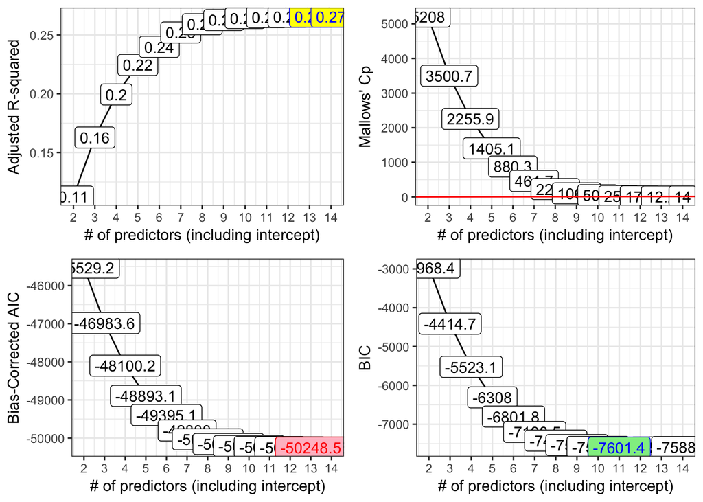

```r
p1<- ggplot(rs.sum, aes(x = k, y = adjr2,label = round(adjr2,2))) +
  geom_line() +
  geom_label() +
  geom_label(data = subset(rs.sum,adjr2 == max(adjr2)),aes(x = k, y = adjr2, label = round(adjr2,2)),
             fill = "yellow", col = "blue") + theme_bw() +
  scale_x_continuous(breaks = 2:14) +
  labs(x = "# of predictors (including intercept)",y = "Adjusted R-squared")

p2<- ggplot(rs.sum, aes(x = k, y = cp,
                   label = round(cp,1))) +
  geom_line() +geom_label() +geom_abline(intercept = 0, slope = 1,col = "red") + theme_bw() +
  scale_x_continuous(breaks = 2:14) +
  labs(x = "# of predictors (including intercept)",y = "Mallows' Cp")

p3<- ggplot(rs.sum, aes(x = k, y = aic.c,label = round(aic.c,1))) +geom_line() +
  geom_label() +geom_label(data = subset(rs.sum, aic.c == min(aic.c)),aes(x = k, y = aic.c), fill = "pink",
                           col = "red") + theme_bw() +
  scale_x_continuous(breaks = 2:14) +labs(x = "# of predictors (including intercept)",y = "Bias-Corrected AIC")

p4<- ggplot(rs.sum, aes(x = k, y = bic,label = round(bic,1))) +
  geom_line() +
  geom_label() +
  geom_label(data = subset(rs.sum, bic == min(bic)),aes(x = k, y = bic),fill = "lightgreen", col = "blue") + theme_bw() +
  scale_x_continuous(breaks = 2:14) +
  labs(x = "# of predictors (including intercept)",y = "BIC")
gridExtra::grid.arrange(p1, p2, p3, p4, nrow = 2)
```

# Candidate Models from Best Subsets

The models we’ll consider are:

[output not shown]

```r
glm9 <- glm(income~age+education+education.num+marital.status+relationship+sex+capital.gain+capital.loss+hours.per.week,data = train,family = binomial)
glm10 <- glm(income~age+education+education.num+marital.status+relationship+sex+capital.gain+capital.loss+hours.per.week+race,data = train,family = binomial)
glm12 <- glm(income~age+education+education.num+marital.status+relationship+sex+capital.gain+capital.loss+hours.per.week+occupation
             +race+workclass,data = train,family = binomial)
glm0<-glm(income~1, data = train, family = binomial)
```

```r
anova(glm12,glm10,glm9,glm0)
```

```
Analysis of Deviance Table

Model 1: income ~ age + education + education.num + marital.status + relationship +
    sex + capital.gain + capital.loss + hours.per.week + occupation +
    race + workclass
Model 2: income ~ age + education + education.num + marital.status + relationship +
    sex + capital.gain + capital.loss + hours.per.week + race
Model 3: income ~ age + education + education.num + marital.status + relationship +
    sex + capital.gain + capital.loss + hours.per.week
Model 4: income ~ 1
  Resid. Df Resid. Dev  Df Deviance
1     24954      16220
2     24976      16365 -22   -145.7
3     24980      16387  -4    -21.8
4     24999      27549 -19 -11162.3
```

```r
pchisq( 21.824, 4, lower.tail = FALSE)
```

```
[1] 0.0002172518
```

```r
pchisq( 145.728, 22, lower.tail = FALSE)
```

```
[1] 3.047793e-20
```

```r
pchisq( 11162.3, 19, lower.tail = FALSE)
```

```
[1] 0
```

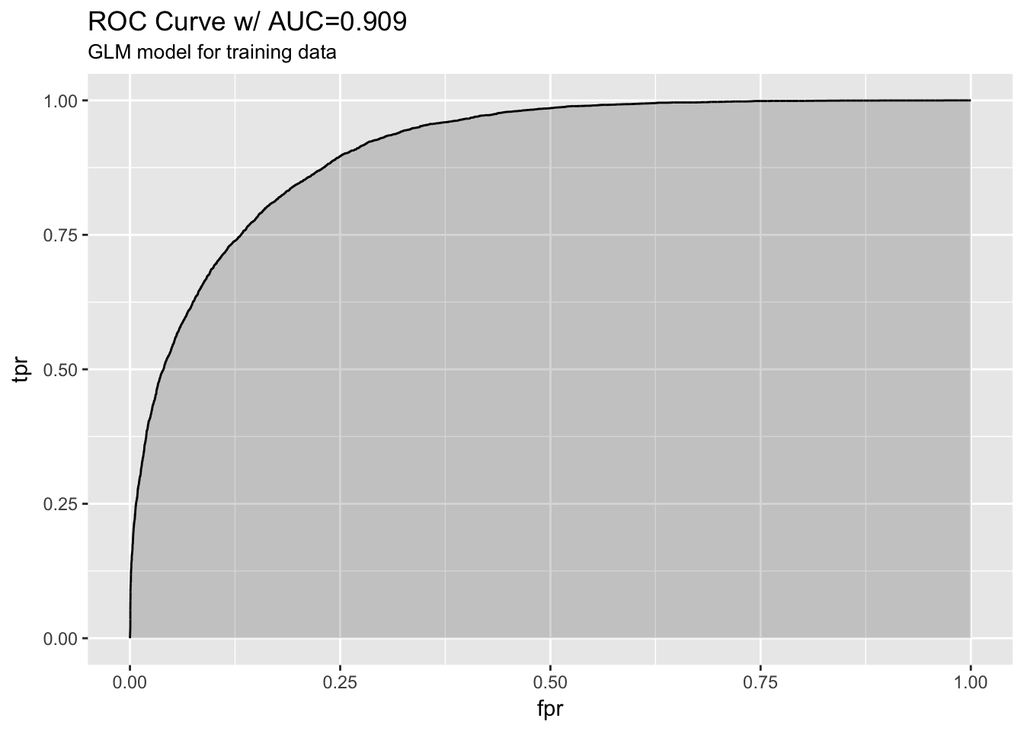

```r
prob <- predict(glm12, data = train, type="response")
pred <- prediction(prob, train$income)
# rest of this doesn't need much adjustment except for titles
perf <- performance(pred, measure = "tpr", x.measure = "fpr")
auc <- performance(pred, measure="auc")
auc <- round(auc@y.values[[1]],3)
roc.data <- data.frame(fpr=unlist(perf@x.values),
                       tpr=unlist(perf@y.values),
                       model="GLM")
ggplot(roc.data, aes(x=fpr, ymin=0, ymax=tpr)) +
    geom_ribbon(alpha=0.2) +
    geom_line(aes(y=tpr)) +
    labs(title = paste0("ROC Curve w/ AUC=", auc),
         subtitle = "GLM model for training data")
```

Based on the C statistic (AUC = 0.909) this would rank somewhere near the high end of a pretty good predictive model by the ROC curve standard.

# Check the Predictability of best subset model

```r
glm.probs = predict(glm12, test, type ="response")
glm.pred = rep(0, length(glm.probs))
glm.pred[glm.probs >0.5] <- 1
table(glm.pred, test$income)
```

```
glm.pred    0    1
       0 5310  771
       1  408 1072
```

```r
mean(glm.pred!= test$income)
```

```
[1] 0.1559318
```

For the best subset model, the test error rate is 15.59%, which is pretty good.

# Forward and Backward Stepwise Selection

## Forward selection

```r
with(train,
     step(glm(income ~ 1,family = binomial),
          scope=(~ age+workclass+education+education.num+marital.status
                 +occupation+relationship+race+sex+capital.gain+
                   capital.loss+hours.per.week+native.country),
     direction="forward"))
```

```
Start:  AIC=27551.38
income ~ 1

                 Df Deviance   AIC
+ relationship    5    21750 21762
+ marital.status  6    22015 22029
+ occupation     14    24357 24387
+ education.num   1    24434 24438
+ education       2    24919 24925
+ capital.gain    1    24926 24930
+ hours.per.week  1    26114 26118
+ age             1    26180 26184
+ sex             1    26298 26302
+ workclass       8    26824 26842
+ capital.loss    1    27039 27043
+ race            4    27254 27264
+ native.country  1    27514 27518
<none>                 27549 27551

Step:  AIC=21761.98
income ~ relationship

                 Df Deviance   AIC
+ education.num   1    19089 19103
+ education       2    19442 19458
+ occupation     14    19429 19469
+ capital.gain    1    19679 19693
+ hours.per.week  1    21160 21174
+ workclass       8    21371 21399
+ capital.loss    1    21433 21447
+ age             1    21549 21563
+ marital.status  6    21617 21641
+ sex             1    21645 21659
+ race            4    21662 21682
+ native.country  1    21705 21719
<none>                 21750 21762

Step:  AIC=19103.37
income ~ relationship + education.num

```

[output cut: 115 more lines]

```
                 Df Deviance   AIC
+ native.country  1    15721 15803
+ race            4    15716 15804
<none>                 15732 15812
+ education       2    15732 15816

Step:  AIC=15802.64
income ~ relationship + education.num + capital.gain + occupation +
    capital.loss + hours.per.week + age + sex + marital.status +
    workclass + native.country

            Df Deviance   AIC
<none>            15721 15803
+ race       4    15714 15804
+ education  2    15727 15813
```

```
Call:  glm(formula = income ~ relationship + education.num + capital.gain +
    occupation + capital.loss + hours.per.week + age + sex +
    marital.status + workclass + native.country, family = binomial)

Coefficients:
                         (Intercept)            relationship Not-in-family           relationship Other-relative                relationship Own-child                relationship Unmarried
                          -9.935e+00                             6.673e-01                            -1.674e-01                            -5.617e-01                             5.064e-01
                   relationship Wife                         education.num                          capital.gain               occupation Adm-clerical               occupation Armed-Forces
                           1.409e+00                             2.824e-01                             3.245e-04                            -7.246e+12                            -7.246e+12
             occupation Craft-repair            occupation Exec-managerial            occupation Farming-fishing          occupation Handlers-cleaners          occupation Machine-op-inspct
                          -7.246e+12                            -7.246e+12                            -7.246e+12                            -7.246e+12                            -7.246e+12
            occupation Other-service            occupation Priv-house-serv             occupation Prof-specialty            occupation Protective-serv                      occupation Sales
                          -7.246e+12                            -7.246e+12                            -7.246e+12                            -7.246e+12                            -7.246e+12
             occupation Tech-support           occupation Transport-moving                          capital.loss                        hours.per.week                                   age
                          -7.246e+12                            -7.246e+12                             6.475e-04                             3.149e-02                             2.740e-02
                            sex Male      marital.status Married-AF-spouse     marital.status Married-civ-spouse  marital.status Married-spouse-absent          marital.status Never-married
                           9.134e-01                             3.011e+00                             2.288e+00                            -5.722e-02                            -5.261e-01
            marital.status Separated                marital.status Widowed                 workclass Federal-gov                   workclass Local-gov                workclass Never-worked
                          -5.126e-02                            -3.838e-03                             7.246e+12                             7.246e+12                            -2.309e+01
                   workclass Private                workclass Self-emp-inc            workclass Self-emp-not-inc                   workclass State-gov                 workclass Without-pay
                           7.246e+12                             7.246e+12                             7.246e+12                             7.246e+12                             7.246e+12
                native.countryNon-US
                          -2.576e-01

Degrees of Freedom: 24999 Total (i.e. Null);  24959 Residual
Null Deviance:      27550
Residual Deviance: 15720    AIC: 15800
```

Forward selection includes 11 variables including `relationship`,`education.num`,`capital.gain`,occupation`,`capital.loss`,`hours.per.week`,`age`,`sex`,`marital.status`,`workclass`and`native.country`.

```r
fwd <- glm(formula = income ~ relationship + education.num + capital.gain +
    occupation + capital.loss + hours.per.week + age + sex +
    marital.status + workclass + native.country, family = binomial,data = train)
```

## ROC for forward selection model

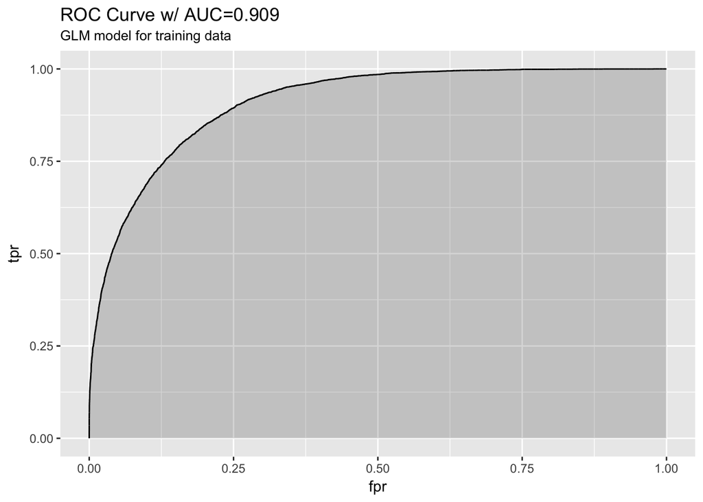

```r
prob <- predict(fwd, data = train, type="response")
pred <- prediction(prob, train$income)
# rest of this doesn't need much adjustment except for titles
perf <- performance(pred, measure = "tpr", x.measure = "fpr")
auc <- performance(pred, measure="auc")
auc <- round(auc@y.values[[1]],3)
roc.data <- data.frame(fpr=unlist(perf@x.values),
                       tpr=unlist(perf@y.values),
                       model="GLM")
ggplot(roc.data, aes(x=fpr, ymin=0, ymax=tpr)) +
    geom_ribbon(alpha=0.2) +
    geom_line(aes(y=tpr)) +
    labs(title = paste0("ROC Curve w/ AUC=", auc),
         subtitle = "GLM model for training data")
```

## Check Predictability

```r
fwd.probs = predict(fwd, test, type ="response")
fwd.pred = rep(0, length(fwd.probs))
fwd.pred[fwd.probs >0.5] <- 1
table(fwd.pred, test$income)
```

```
fwd.pred    0    1
       0 5310  789
       1  408 1054
```

```r
mean(fwd.pred!= test$income)
```

```
[1] 0.1583124
```

For the model selected by forward selection method, the test error rate is 15.83%, which is pretty good.

## Backward selection

```r
with(train,
     step(glm(income ~ age+workclass+education+education.num+marital.status
                 +occupation+relationship+race+sex+capital.gain+
                   capital.loss+hours.per.week+native.country,family = binomial),
         direction="backward"))
```

```
Start:  AIC=15795.68
income ~ age + workclass + education + education.num + marital.status +
    occupation + relationship + race + sex + capital.gain + capital.loss +
    hours.per.week + native.country

                 Df Deviance   AIC
- education       2    15705 15793
<none>                 15704 15796
- race            4    15717 15801
- native.country  1    15715 15805
- workclass       7    15804 15882
- marital.status  6    15806 15886
- sex             1    15803 15893
- education.num   1    15886 15976
- age             1    15921 16011
- relationship    5    15929 16011
- capital.loss    1    15945 16035
- hours.per.week  1    16003 16093
- occupation     13    16158 16224
- capital.gain    1    17165 17255

Step:  AIC=15793.45
income ~ age + workclass + education.num + marital.status + occupation +
    relationship + race + sex + capital.gain + capital.loss +
    hours.per.week + native.country

                 Df Deviance   AIC
<none>                 15705 15793
- race            4    15718 15798
- native.country  1    15716 15802
- workclass       7    15806 15880
- marital.status  6    15808 15884
- sex             1    15805 15891
- relationship    5    15931 16009
- age             1    15925 16011
- capital.loss    1    15947 16033
- hours.per.week  1    16004 16090
- occupation     13    16172 16234
- education.num   1    16509 16595
- capital.gain    1    17167 17253
```

```
Call:  glm(formula = income ~ age + workclass + education.num + marital.status +
    occupation + relationship + race + sex + capital.gain + capital.loss +
    hours.per.week + native.country, family = binomial)

Coefficients:
                         (Intercept)                                   age                 workclass Federal-gov                   workclass Local-gov                workclass Never-worked
                          -1.056e+01                             2.736e-02                             1.032e+00                             2.927e-01                            -9.550e+00
                   workclass Private                workclass Self-emp-inc            workclass Self-emp-not-inc                   workclass State-gov                 workclass Without-pay
                           5.469e-01                             6.676e-01                             4.421e-02                             1.888e-01                            -1.153e+01
                       education.num      marital.status Married-AF-spouse     marital.status Married-civ-spouse  marital.status Married-spouse-absent          marital.status Never-married
                           2.813e-01                             2.987e+00                             2.282e+00                            -4.260e-02                            -5.250e-01
            marital.status Separated                marital.status Widowed               occupation Adm-clerical               occupation Armed-Forces               occupation Craft-repair
                          -4.399e-02                            -3.796e-03                             7.671e-02                            -6.984e-01                             1.464e-01
          occupation Exec-managerial            occupation Farming-fishing          occupation Handlers-cleaners          occupation Machine-op-inspct              occupation Other-service
                           8.787e-01                            -8.196e-01                            -5.000e-01                            -2.893e-01                            -8.330e-01
          occupation Priv-house-serv             occupation Prof-specialty            occupation Protective-serv                      occupation Sales               occupation Tech-support
                          -3.574e+00                             6.424e-01                             6.715e-01                             3.432e-01                             7.450e-01
         occupation Transport-moving            relationship Not-in-family           relationship Other-relative                relationship Own-child                relationship Unmarried
                                  NA                             6.671e-01                            -1.651e-01                            -5.749e-01                             5.132e-01
                   relationship Wife               race Asian-Pac-Islander                            race Black                            race Other                            race White
                           1.411e+00                             6.850e-01                             5.429e-01                             3.622e-03                             6.508e-01
                            sex Male                          capital.gain                          capital.loss                        hours.per.week                  native.countryNon-US
                           9.016e-01                             3.257e-04                             6.482e-04                             3.159e-02                            -2.560e-01

Degrees of Freedom: 24999 Total (i.e. Null);  24956 Residual
Null Deviance:      27550
Residual Deviance: 15710    AIC: 15790
```

```r
bwd<- glm(formula = income ~ age + workclass + education.num + marital.status +
    occupation + relationship + race + sex + capital.gain + capital.loss +
    hours.per.week + native.country, family = binomial(link = logit),data = train)
```

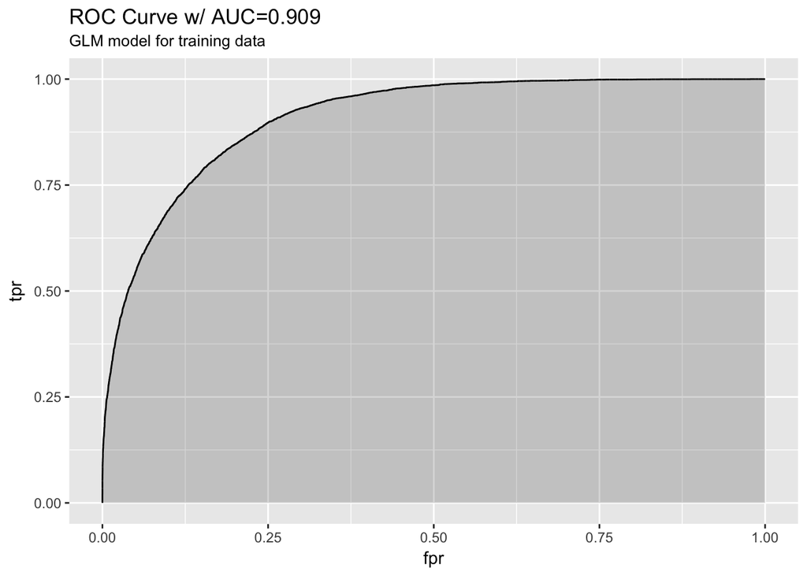

```r
prob <- predict(bwd, data = train, type="response")
pred <- prediction(prob, train$income)
# rest of this doesn't need much adjustment except for titles
perf <- performance(pred, measure = "tpr", x.measure = "fpr")
auc <- performance(pred, measure="auc")
auc <- round(auc@y.values[[1]],3)
roc.data <- data.frame(fpr=unlist(perf@x.values),
                       tpr=unlist(perf@y.values),
                       model="GLM")
ggplot(roc.data, aes(x=fpr, ymin=0, ymax=tpr)) +
    geom_ribbon(alpha=0.2) +
    geom_line(aes(y=tpr)) +
    labs(title = paste0("ROC Curve w/ AUC=", auc),
         subtitle = "GLM model for training data")
```

The backward method returns thefinal model, which includes 12 variables including `relationship`,`education.num`,`capital.gain`,`occupation`,`capital.loss`,`hours.per.week`,`race`,`age`,`sex`,`marital.status`,`workclass`,and `native.country`.

## Check Predictability

```r
bwd.probs = predict(bwd, test, type ="response")
bwd.pred = rep(0, length(bwd.probs))
bwd.pred[bwd.probs >0.5] <- 1
table(bwd.pred, test$income)
```

```
bwd.pred    0    1
       0 5310  776
       1  408 1067
```

```r
mean(bwd.pred!= test$income)
```

```
[1] 0.156593
```

# Ridge Regression

```r
x <- model.matrix(income ~ .-fnlwgt, data = train)[,-1]
y <- train$income
x <- scale(x)
grid<- 10^seq(10,-2,length=100)
```

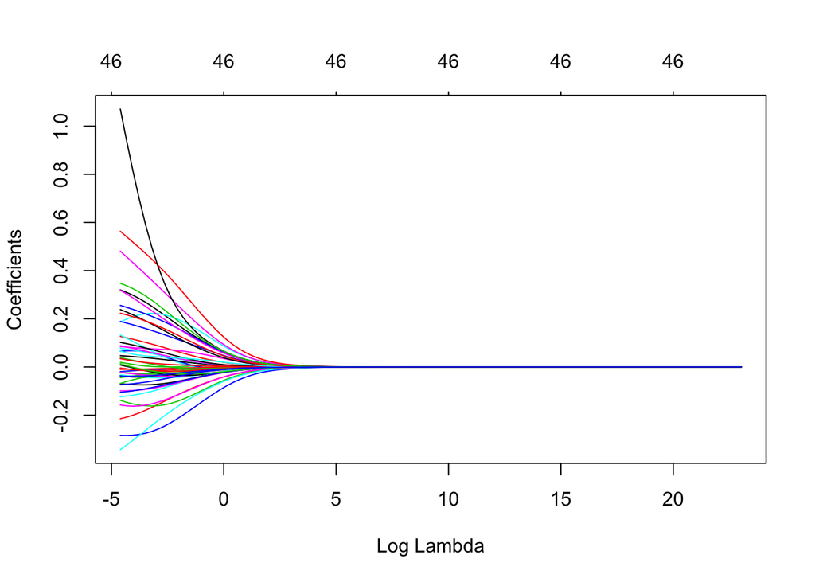

```r
library(glmnet)
ridge <- glmnet(x, y, alpha = 0, lambda = grid, family = "binomial")
plot(ridge, xvar="lambda")
```

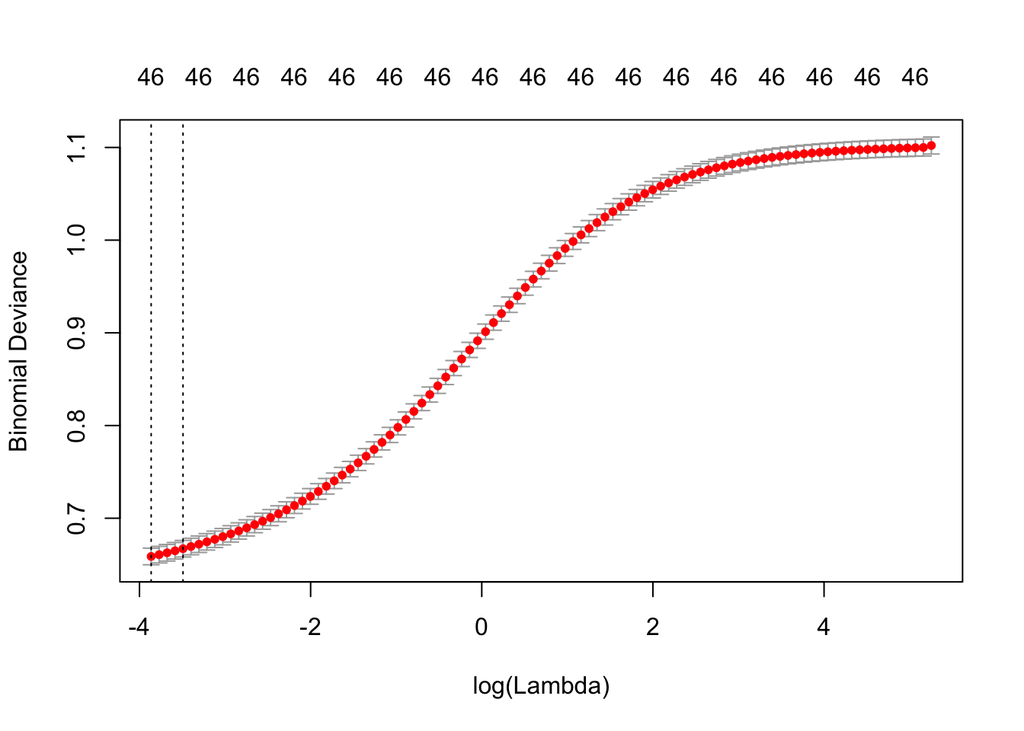

```r
cv.ridge <-cv.glmnet(x,y,alpha=0, family = "binomial")
plot(cv.ridge)
```

```r
bestlam.ridge <- cv.ridge$lambda.min
bestlam.ridge
```

```
[1] 0.02099622
```

```r
predict(ridge, s=bestlam.ridge, type = "coefficients")
```

```
47 x 1 sparse Matrix of class "dgCMatrix"
                                                1
(Intercept)                          -1.855759151
age                                   0.289434628
workclass Federal-gov                 0.111329436
workclass Local-gov                   0.008521076
workclass Never-worked               -0.014484927
workclass Private                     0.097878553
workclass Self-emp-inc                0.079155547
workclass Self-emp-not-inc           -0.041950237
workclass State-gov                  -0.011920739
workclass Without-pay                -0.035053995
educationsome college                 0.066818893
educationBachelors and above          0.213565708
education.num                         0.418365476
marital.status Married-AF-spouse      0.041965444
marital.status Married-civ-spouse     0.504075976
marital.status Married-spouse-absent -0.026491356
marital.status Never-married         -0.281320602
marital.status Separated             -0.039902121
marital.status Widowed               -0.029801982
occupation Adm-clerical              -0.007349382
occupation Armed-Forces              -0.009210186
occupation Craft-repair               0.024678413
occupation Exec-managerial            0.233686910
occupation Farming-fishing           -0.114311636
occupation Handlers-cleaners         -0.096521078
occupation Machine-op-inspct         -0.073527425
occupation Other-service             -0.194230746
occupation Priv-house-serv           -0.049424658
occupation Prof-specialty             0.170530501
occupation Protective-serv            0.067272749
occupation Sales                      0.073601671
occupation Tech-support               0.087656927
occupation Transport-moving          -0.012222172
relationship Not-in-family           -0.156219018
relationship Other-relative          -0.096520921
relationship Own-child               -0.291946641
relationship Unmarried               -0.161962685
relationship Wife                     0.209129204
race Asian-Pac-Islander               0.023210063
race Black                           -0.004583987
race Other                           -0.038430048
race White                            0.050816876
sex Male                              0.276202535
capital.gain                          0.742737936
capital.loss                          0.203695906
hours.per.week                        0.316550631
native.countryNon-US                 -0.067555136
```

The smallest lambda is 0.021 using the cross-validation methods.

```r
testx <- model.matrix(income~.-fnlwgt, data = test)
ridge.probs = predict(ridge,  s = bestlam.ridge, newx = testx)
ridge.pred = rep(0, length(ridge.probs))
ridge.pred[ridge.probs >0.5] <- 1
table(ridge.pred, test$income)
```

```
ridge.pred    0    1
         1 5718 1843
```

```r
mean(ridge.pred!= test$income)
```

```
[1] 0.7562492
```

# lasso Regression

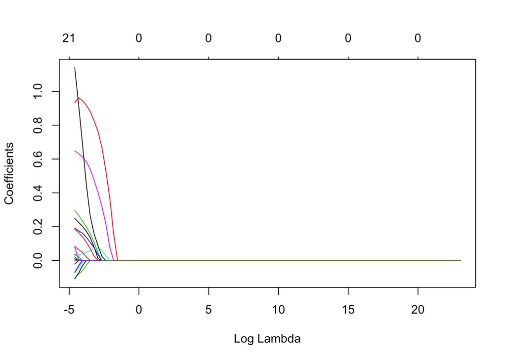

```r
lasso <- glmnet(x, y, alpha = 1, lambda = grid, family = "binomial")
plot(lasso, xvar="lambda")
```

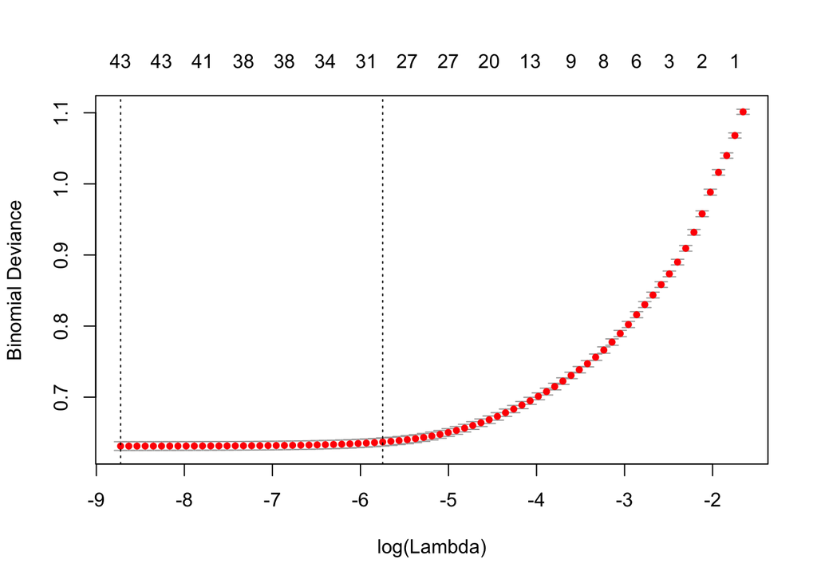

```r
cv.lasso <-cv.glmnet(x,y,alpha=1, family = "binomial")
plot(cv.lasso)
```

```r
bestlam.lasso <- cv.lasso$lambda.min
bestlam.lasso
```

```
[1] 0.0001625661
```

```r
predict(lasso, s=bestlam.lasso, type = "coefficients")
```

```
47 x 1 sparse Matrix of class "dgCMatrix"
                                                 1
(Intercept)                          -1.7168153871
age                                   0.2491328870
workclass Federal-gov                 0.0367936628
workclass Local-gov                   .
workclass Never-worked                .
workclass Private                     .
workclass Self-emp-inc                0.0149392435
workclass Self-emp-not-inc           -0.0212565031
workclass State-gov                   .
workclass Without-pay                 .
educationsome college                 .
educationBachelors and above          0.0285296551
education.num                         0.6491686280
marital.status Married-AF-spouse      0.0098392643
marital.status Married-civ-spouse     0.9329462992
marital.status Married-spouse-absent  .
marital.status Never-married         -0.1077032920
marital.status Separated              .
marital.status Widowed                .
occupation Adm-clerical               .
occupation Armed-Forces               .
occupation Craft-repair               .
occupation Exec-managerial            0.1912710386
occupation Farming-fishing           -0.0686105117
occupation Handlers-cleaners          .
occupation Machine-op-inspct         -0.0005407155
occupation Other-service             -0.1091274725
occupation Priv-house-serv            .
occupation Prof-specialty             0.0839401636
occupation Protective-serv            .
occupation Sales                      .
occupation Tech-support               0.0228834379
occupation Transport-moving           .
relationship Not-in-family            .
relationship Other-relative           .
relationship Own-child               -0.0732674411
relationship Unmarried                .
relationship Wife                     0.0770372563
race Asian-Pac-Islander               .
race Black                            .
race Other                            .
race White                            .
sex Male                              0.0799454041
capital.gain                          1.1405111960
capital.loss                          0.1847009949
hours.per.week                        0.2963372712
native.countryNon-US                  .
```

```r
testx <- model.matrix(income~.-fnlwgt, data = test)
lasso.probs = predict(lasso,s = bestlam.ridge, newx = testx)
lasso.pred = rep(0, length(lasso.probs))
lasso.pred[lasso.probs >0.5] <- 1
table(lasso.pred, test$income)
```

```
lasso.pred    0    1
         1 5718 1843
```

```r
mean(lasso.pred!= test$income)
```

```
[1] 0.7562492
```

The models given by both lasso and ridge have a higher error rate than the model generated before.